# Dataviz - Homework 3

#### Plot 6

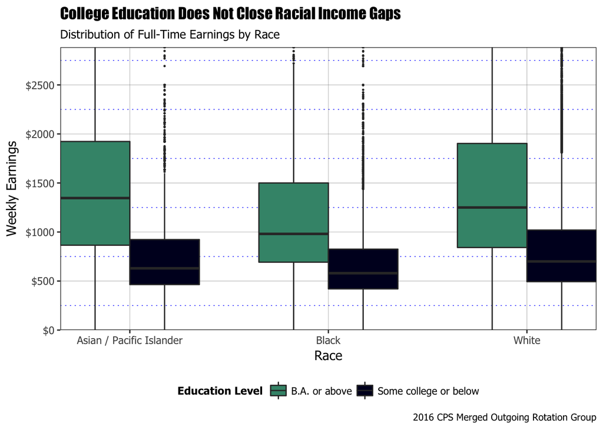

Higher education is often viewed as the great equalizer of social inequities. Generally, those that earn at least Bachelor’s Degree have higher incomes than those who do not complete college, and plot 6 shows that this is true among three racial categories. However, earning a B.A. does not close the gap between Black, Asian, and White workers. In fact, the difference in median incomes is even greater among college-educated workers than non-college-educated workers.

#### Plot 7

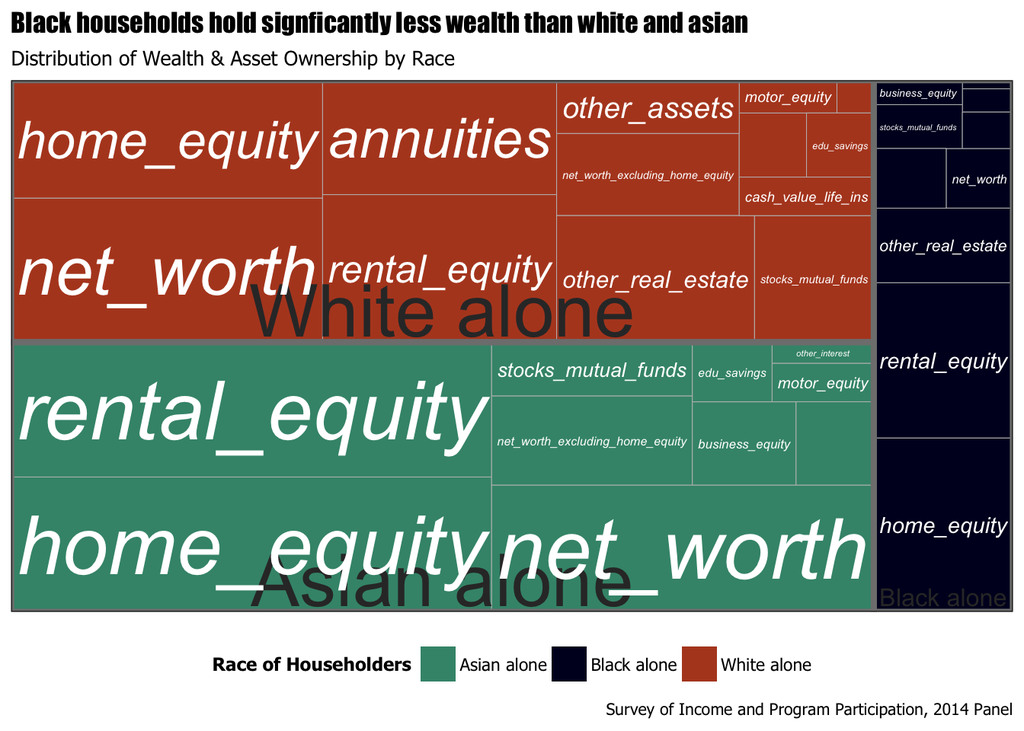